# Presentations in R

Ellen Tedeschi

3/23/2019

# Why should I make my presentation in R?

- No more copying and pasting graphs into powerpoint or keynote.
- Great for data presentations and lab meetings where you need to show lots of graphs.
- Great for tutorials or labs where you want to show code and output.
- Maybe don’t use this when you really really care about how your slides are laid out.

# Controlling your presentation

- There are three areas within the markdown that are important for the look and feel of your presentation.
- In the regular text, you control headings, text styles and outlines using special characters (#,*,+ etc.)
- Within the code chunks
- Within the headers of each code chunk, where you specify what should appear in the final document.

# Arranging your text

1. Hashtags can be used to add headers of various sizes
2. Start lines with numerals for a numbered list, or use (*) for unnumbered lines
3. End a line with two spaces to start a new paragraph.
- See code for how to do:
- *italics*
- **bold**
- superscripts<sup>2</sup>
- strikethrough
- link

# Adding images

[figure not shown]

```r
knitr::include_graphics("Evie.jpg")
```

- In the code header: {r, out.width=“400px”, fig.align=“center”}

# Adding Graphs

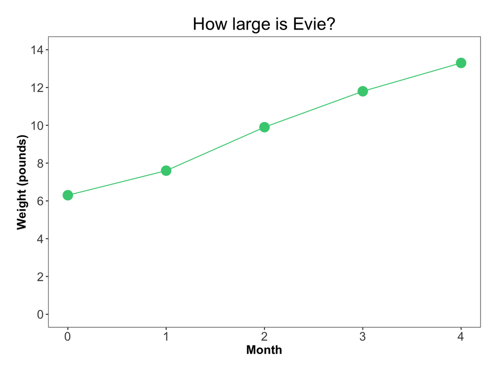

```r
ggplot(BabyData, aes(x=Month, y=Weight)) + geom_point(color="seagreen3", size=5) + geom_line(color="seagreen3") +
  scale_y_continuous(limits=c(0, 14), breaks=seq(0,14,2)) + labs(y="Weight (pounds)", title="How large is Evie?")
```

# Two Graphs, Side by Side

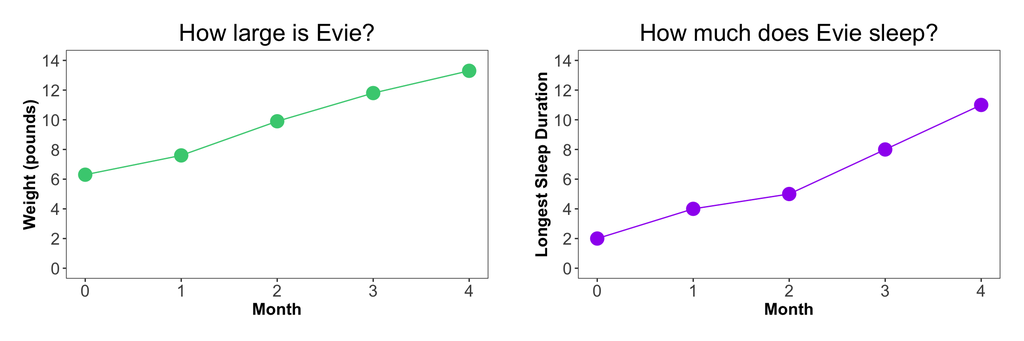

```r
Graph1 <- ggplot(BabyData, aes(x=Month, y=Weight)) + geom_point(color="seagreen3", size=5) +
  geom_line(color="seagreen3") + scale_y_continuous(limits=c(0, 14), breaks=seq(0,14,2)) +
  labs(y="Weight (pounds)", title="How large is Evie?")

Graph2 <- ggplot(BabyData, aes(x=Month, y=SleepLength)) + geom_point(color="purple", size=5) +
  geom_line(color="purple") + scale_y_continuous(limits=c(0, 14), breaks=seq(0,14,2)) +
  labs(y="Longest Sleep Duration", title="How much does Evie sleep?")

grid.arrange(Graph1, Graph2, ncol=2)
```

# Two Graphs, Side by Side, No code

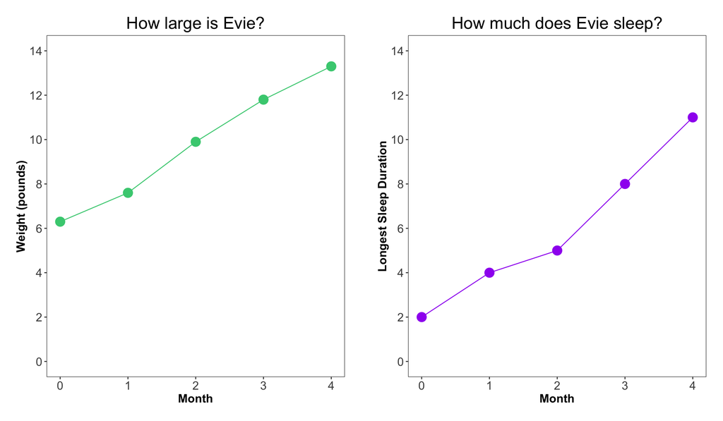

# I want to build in my graphs!

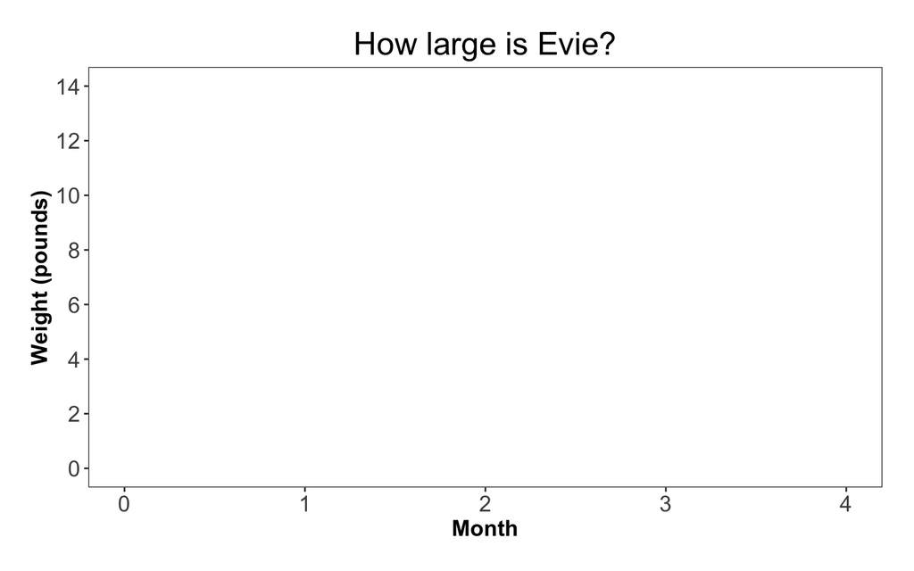

```r
# Build an empty plot
BuildGraph <- ggplot(BabyData, aes(x=Month, y=Weight)) + scale_y_continuous(limits=c(0, 14), breaks=seq(0,14,2)) +
  labs(y="Weight (pounds)", title="How large is Evie?")

grid.arrange(BuildGraph)
```

# I want to build in my graphs!

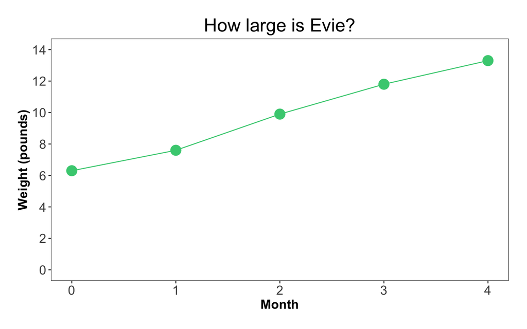

```r
# Add onto your empty plot in a second slide
BuildGraph <- BuildGraph +
  geom_point(color="seagreen3", size=5) + geom_line(color="seagreen3")

grid.arrange(BuildGraph)
```

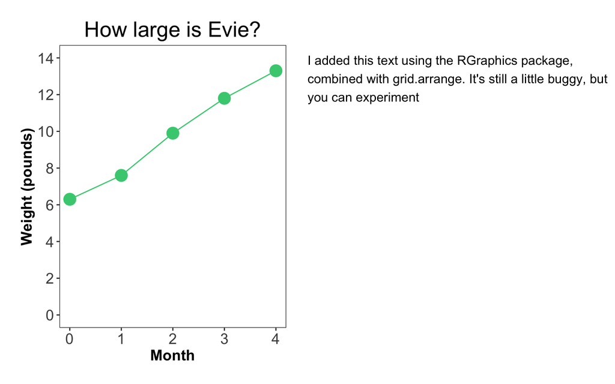

```r
# Text
text <- "\n\n\nI added this text using the RGraphics package, combined with grid.arrange. It's still a little buggy, but you can experiment"
p2 <- splitTextGrob(text)
# Arrange the plots on the same page
grid.arrange(BuildGraph, p2, ncol=2)
```

# Include Code and Output: {r, No extra arguments}

```r
test <- lm(Weight~Month, data=BabyData)
summary(test)
```

```
##
## Call:
## lm(formula = Weight ~ Month, data = BabyData)
##
## Residuals:
##     1     2     3     4     5
##  0.16 -0.36  0.12  0.20 -0.12
##
## Coefficients:
##             Estimate Std. Error t value Pr(>|t|)
## (Intercept)  6.14000    0.21166   29.01    9e-05 ***
## Month        1.82000    0.08641   21.06 0.000234 ***
## ---
## Signif. codes:  0 '***' 0.001 '**' 0.01 '*' 0.05 '.' 0.1 ' ' 1
##
## Residual standard error: 0.2733 on 3 degrees of freedom
## Multiple R-squared:  0.9933, Adjusted R-squared:  0.991
## F-statistic: 443.6 on 1 and 3 DF,  p-value: 0.0002341
```

# No Code, Only Output: {r, echo=FALSE}

```
##
## Call:
## lm(formula = Weight ~ Month, data = BabyData)
##
## Residuals:
##     1     2     3     4     5
##  0.16 -0.36  0.12  0.20 -0.12
##
## Coefficients:
##             Estimate Std. Error t value Pr(>|t|)
## (Intercept)  6.14000    0.21166   29.01    9e-05 ***
## Month        1.82000    0.08641   21.06 0.000234 ***
## ---
## Signif. codes:  0 '***' 0.001 '**' 0.01 '*' 0.05 '.' 0.1 ' ' 1
##
## Residual standard error: 0.2733 on 3 degrees of freedom
## Multiple R-squared:  0.9933, Adjusted R-squared:  0.991
## F-statistic: 443.6 on 1 and 3 DF,  p-value: 0.0002341
```

# No Output, Only Code: {r, eval=FALSE}

```r
test <- lm(Weight~Month, data=BabyData)
summary(test)
```